# STOR 455 Homework 1

```r
library(mosaic)
library(readr)
library(Stat2Data)

data("HighPeaks")
data("Perch")
```

```r
head(HighPeaks)
```

|  | Peak | Elevation | Difficulty | Ascent | Length | Time |
| --- | --- | --- | --- | --- | --- | --- |
| 1 | Mt. Marcy | 5344 | 5 | 3166 | 14.8 | 10.0 |
| 2 | Algonquin Peak | 5114 | 5 | 2936 | 9.6 | 9.0 |
| 3 | Mt. Haystack | 4960 | 7 | 3570 | 17.8 | 12.0 |
| 4 | Mt. Skylight | 4926 | 7 | 4265 | 17.9 | 15.0 |
| 5 | Whiteface Mtn. | 4867 | 4 | 2535 | 10.4 | 8.5 |
| 6 | Dix Mtn. | 4857 | 5 | 2800 | 13.2 | 10.0 |

```r
head(Perch)
```

|  | Obs | Weight | Length | Width |
| --- | --- | --- | --- | --- |
| 1 | 104 | 5.9 | 8.8 | 1.4 |
| 2 | 105 | 32.0 | 14.7 | 2.0 |
| 3 | 106 | 40.0 | 16.0 | 2.4 |
| 4 | 107 | 51.5 | 17.2 | 2.6 |
| 5 | 108 | 70.0 | 18.5 | 2.9 |
| 6 | 109 | 100.0 | 19.2 | 3.3 |

Question 1, Part A

```r
HighestPeaksMod = lm(Time~Ascent, data=HighPeaks)
HighestPeaksMod
```

```
##
## Call:
## lm(formula = Time ~ Ascent, data = HighPeaks)
##
## Coefficients:
## (Intercept)       Ascent
##    4.210054     0.002081
```

The equation is Time = 4.210054 + 0.002081(Ascent)

Question 1, Part B

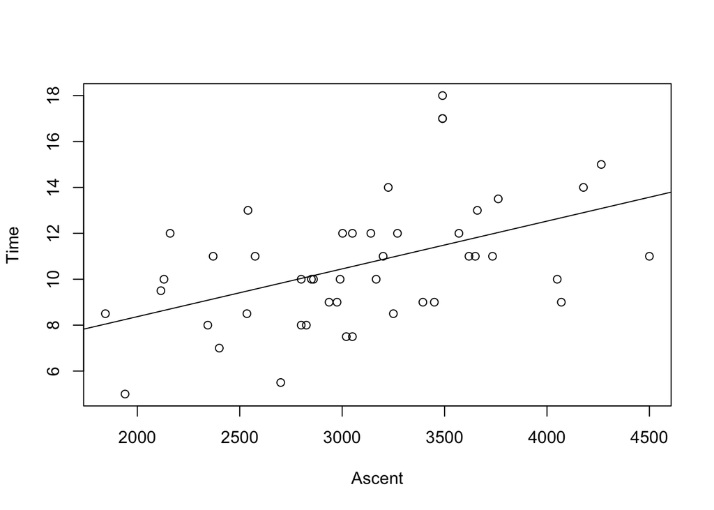

```r
plot(Time~Ascent, data=HighPeaks)
abline(HighestPeaksMod)
```

Question 1, Part C

```r
HighPeaks[HighPeaks$Peak == "Couchsachraga Peak ", ]
```

|  | Peak | Elevation | Difficulty | Ascent | Length | Time |
| --- | --- | --- | --- | --- | --- | --- |
| 46 | Couchsachraga Peak | 3820 | 6 | 3140 | 15 | 12 |

Based on the Ascent time of Couchsachraga Peak, the model would predict the time to climb as follows:

Time = 4.210054 + 0.002081(3140)

```r
Couchsachraga_Time = 4.210054 + 0.002081*3140
Couchsachraga_Time
```

```
## [1] 10.74439
```

Therefore the predicted time it would take to summit Couchsachraga Peak would be 10.74439 hours. The residual is calculated as observed value - predicted value

```r
Couchsachraga_Resid = 12 - Couchsachraga_Time
Couchsachraga_Resid
```

```
## [1] 1.255606
```

Question 1, Part D

Highest Positive Residual means predicted is lower than observed, Largest Negative Residual means that predicted is higher than observed

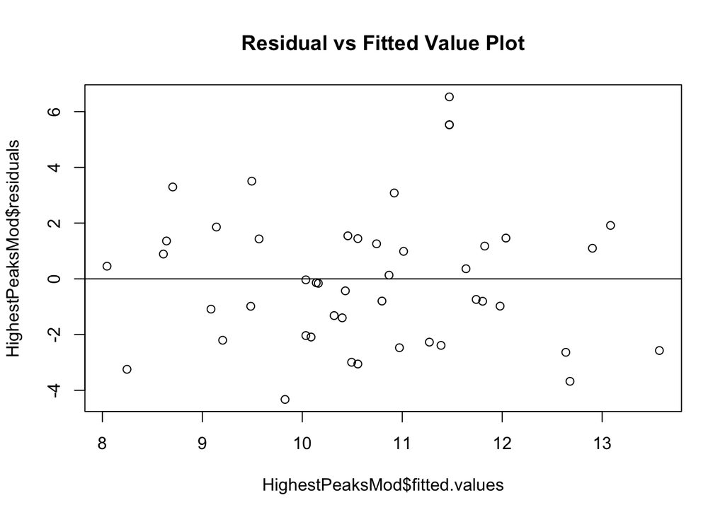

```r
plot(HighestPeaksMod$residuals~HighestPeaksMod$fitted.values)
abline(a=0,b=0)
title("Residual vs Fitted Value Plot")
```

```r
#which.max() shows us the largest positive residual occured at Mt. Emmons
which.max(HighestPeaksMod$residuals)
```

```
## 40
## 40
```

```r
HighPeaks[40, ]
```

|  | Peak | Elevation | Difficulty | Ascent | Length | Time |
| --- | --- | --- | --- | --- | --- | --- |
| 40 | Mt. Emmons | 4040 | 7 | 3490 | 18 | 18 |

```r
#MtEmmons_PredictedTime is a variable that store the Time our model would predict for MtEmmons
MtEmmons_PredictedTime = 4.210054 + 0.002081*HighPeaks[40,]$Ascent
MtEmmons_PredictedTime
```

```
## [1] 11.47274
```

```r
#MtEmmons_Resid is the residual value of the observed Time minus the predicted time
MtEmmons_Resid = 18 - MtEmmons_PredictedTime
MtEmmons_Resid
```

```
## [1] 6.527256
```

Mt.Emmons has the largest positive residual. Its value is 6.527256.

Question 1, Part E

```r
#which.min() gives the smallest residual
which.min(HighestPeaksMod$residuals)
```

```
## 38
## 38
```

```r
HighPeaks[38, ]
```

|  | Peak | Elevation | Difficulty | Ascent | Length | Time |
| --- | --- | --- | --- | --- | --- | --- |
| 38 | Porter Mtn. | 4059 | 3 | 2700 | 7.6 | 5.5 |

```r
#PorterMtn_PredictedTime is a variable that store the Time our model would predict for PorterMtn
PorterMtn_PredictedTime = 4.210054 + 0.002081*HighPeaks[38,]$Ascent
PorterMtn_PredictedTime
```

```
## [1] 9.828754
```

```r
#PorterMtn_Resid is the residual value of the observed Time minus the predicted time
PorterMtn_Resid = 5.5 - PorterMtn_PredictedTime
PorterMtn_Resid
```

```
## [1] -4.328754
```

Porter Mtn. had the largest negative residual. Its value is -4.328754.

Question 1, Part F

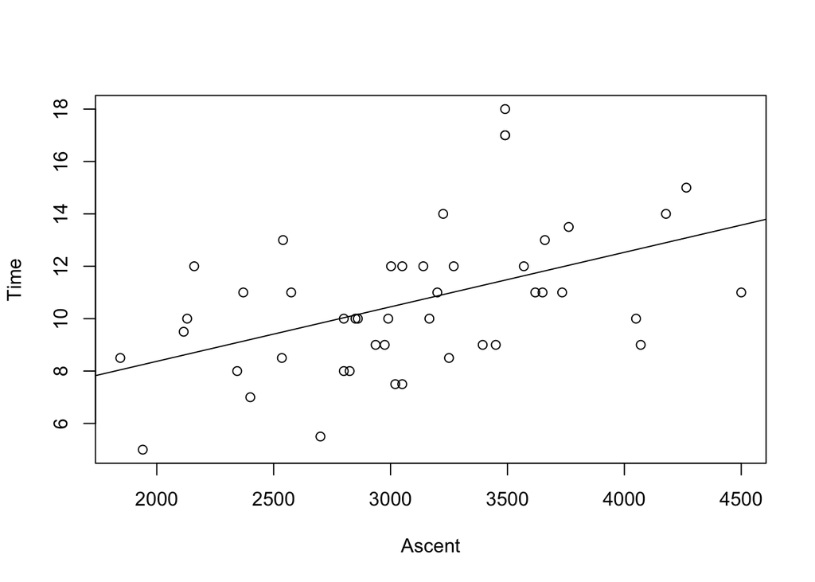

```r
#Shows Linearity kind of, but there is a large spread around the line
plot(Time~Ascent, data=HighPeaks)
abline(HighestPeaksMod)
```

The above plot shows scatter plot of Ascent and Time. There is a weak, positive linear trend we can observe here. It seems like a linear model would be appropriate to use in this case.

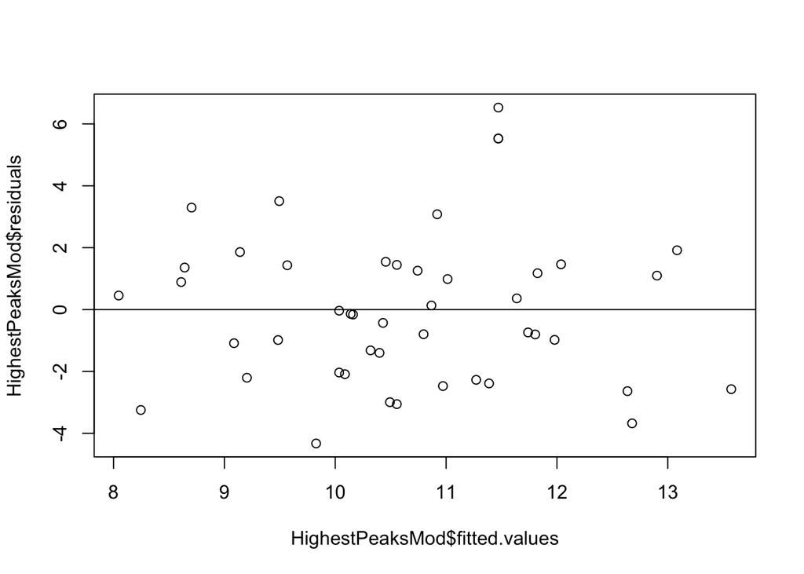

```r
#Shows Zero Mean
plot(HighestPeaksMod$residuals~HighestPeaksMod$fitted.values)
abline(0,0)
```

The above plot shows the plot of the residuals and the fitted values from our model. The residuals seem to be randomly distbuted over the zero mean reference line. We can assume zero mean from this plot. This is another satisifed condition of using a linear model.

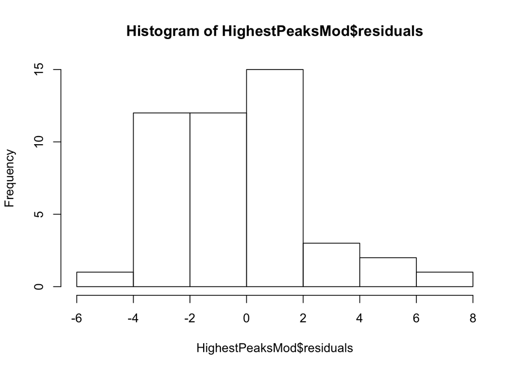

```r
#Shows Independence and skewness (or lack of skewness)

hist(HighestPeaksMod$residuals)
```

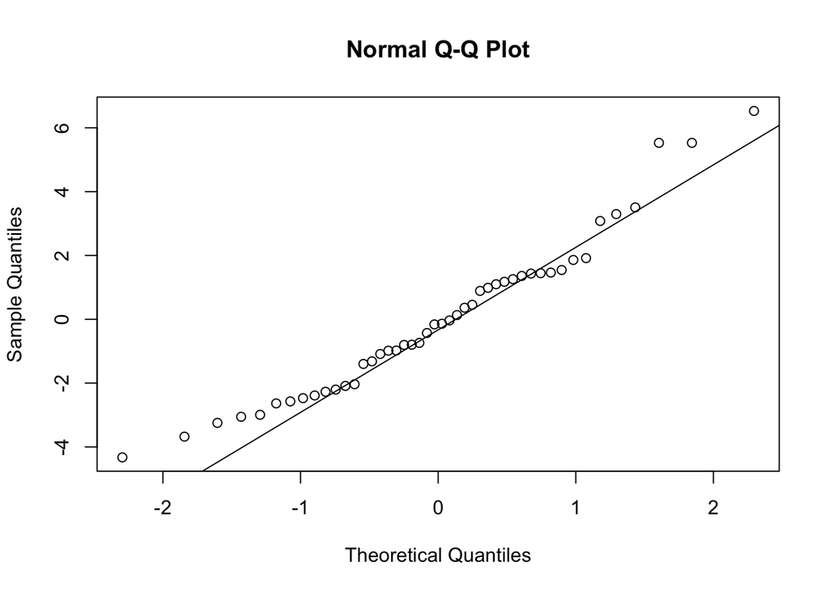

```r
qqnorm(HighestPeaksMod$residuals)
qqline(HighestPeaksMod$residuals)
```

Based on the above plots, a simple linear model feels appropriate to model this relationship.

Question 2, Part A

Make a linear model that used Length to predict Weight

```r
PerchWeightMod = lm(Weight~Length, data = Perch)
PerchWeightMod
```

```
##
## Call:
## lm(formula = Weight ~ Length, data = Perch)
##
## Coefficients:
## (Intercept)       Length
##      -652.8         35.0
```

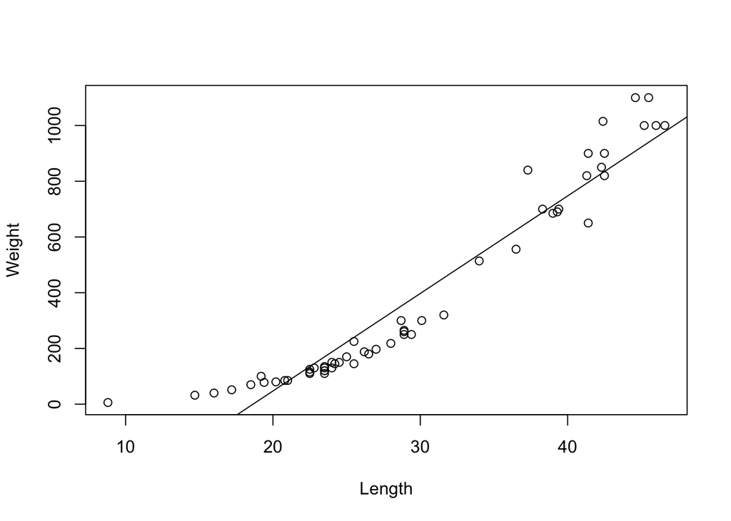

```r
#plot shows a scatter plot of Weigth and Length and the least squares regression line (linear model)

plot(Weight~Length, data = Perch)
abline(PerchWeightMod)
```

Based on the above plot, it is clear the there is a trend between Length of a fish and its Weight, but it doesn’t appear to be linear. Below I will experiment until with transformations until the relationship is more linear.

Question 2, Part B

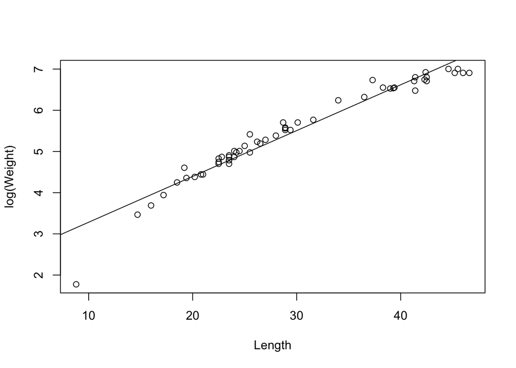

```r
plot(log(Weight)~Length, data=Perch)                #This model does a good job of making the relationship linear
mod1=lm(log(Weight)~Length, data=Perch)
abline(mod1)
```

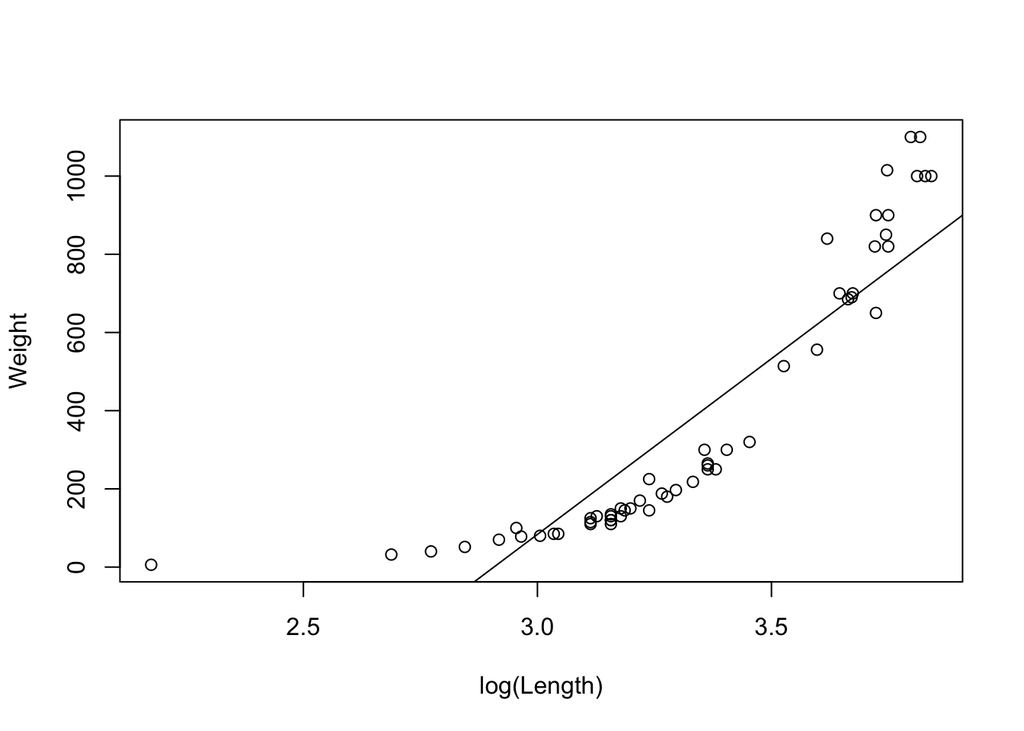

```r
plot(Weight~log(Length), data=Perch)                #This model sucks
mod2=lm(Weight~log(Length), data=Perch)
abline(mod2)
```

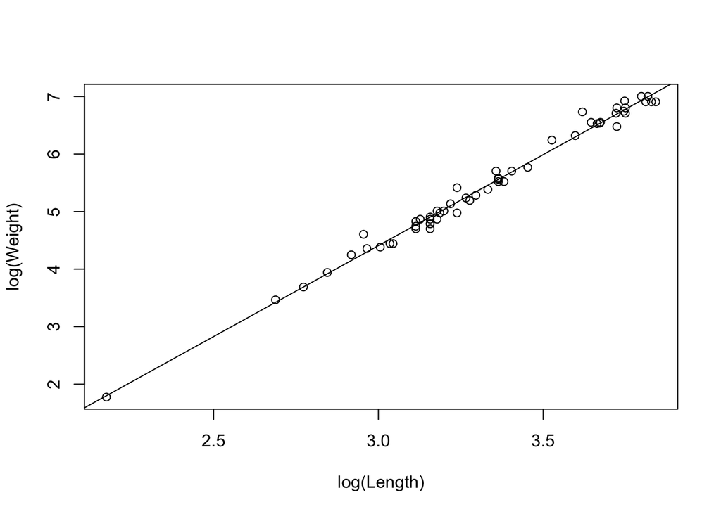

```r
plot(log(Weight)~log(Length), data=Perch)           #This appears to be the best model.
mod3=lm(log(Weight)~log(Length), data=Perch)
abline(mod3)
```

The above plot showing log(Weight)~log(Length) appears to be the best plot. This plot shows the least squares line over the scatterplot of these values. Below is a summary of the linear model.

```r
summary(mod3)
```

```
##
## Call:
## lm(formula = log(Weight) ~ log(Length), data = Perch)
##
## Residuals:
##      Min       1Q   Median       3Q      Max
## -0.21976 -0.07130 -0.00080  0.03965  0.36650
##
## Coefficients:
##             Estimate Std. Error t value Pr(>|t|)
## (Intercept) -5.07884    0.15212  -33.39   <2e-16 ***
## log(Length)  3.16269    0.04542   69.64   <2e-16 ***
## ---
## Signif. codes:  0 '***' 0.001 '**' 0.01 '*' 0.05 '.' 0.1 ' ' 1
##
## Residual standard error: 0.1157 on 54 degrees of freedom
## Multiple R-squared:  0.989,  Adjusted R-squared:  0.9888
## F-statistic:  4849 on 1 and 54 DF,  p-value: < 2.2e-16
```

Question 2, Part C

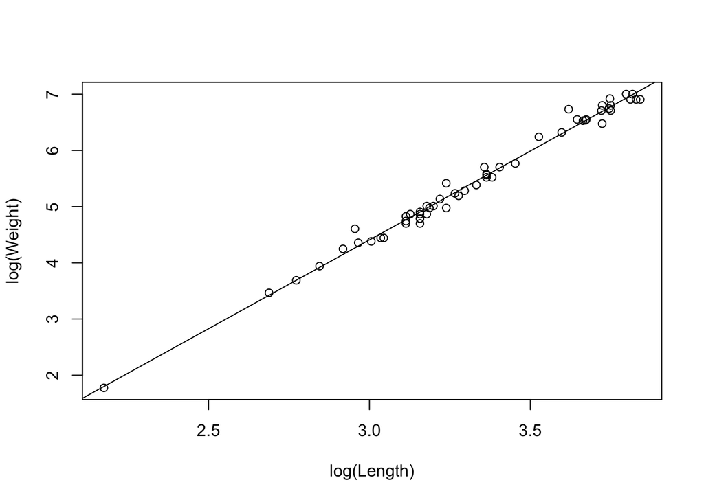

```r
plot(log(Weight)~log(Length), data=Perch)
abline(mod3)
```

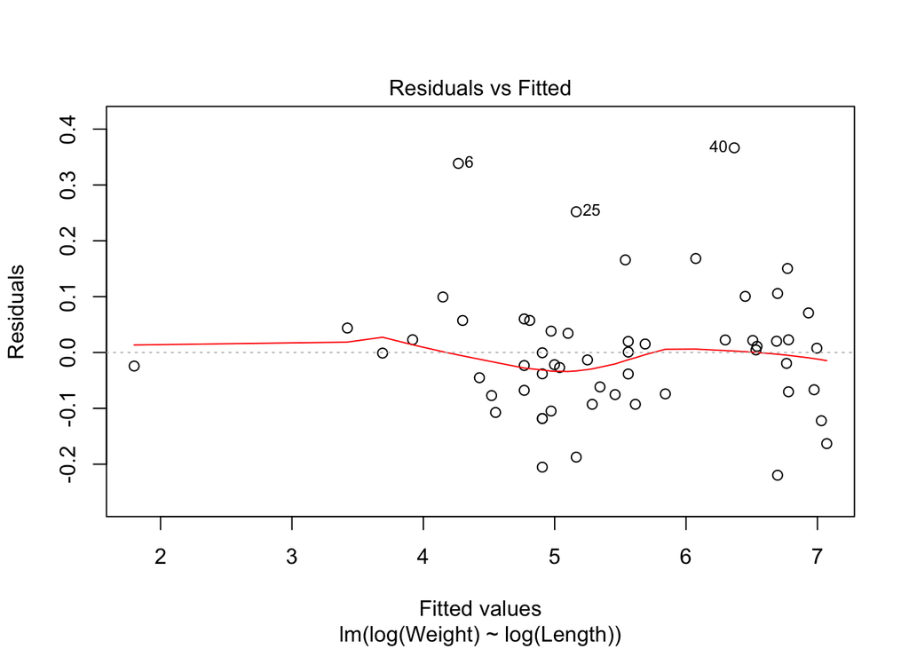

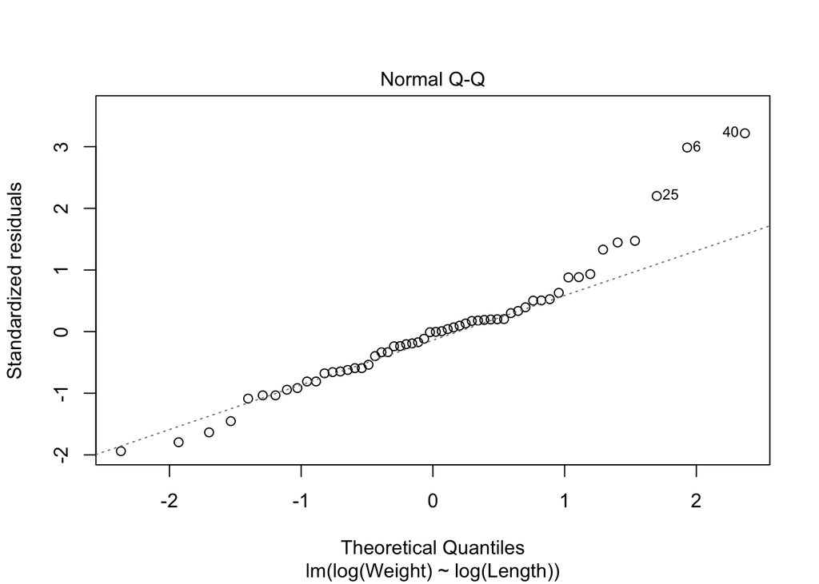

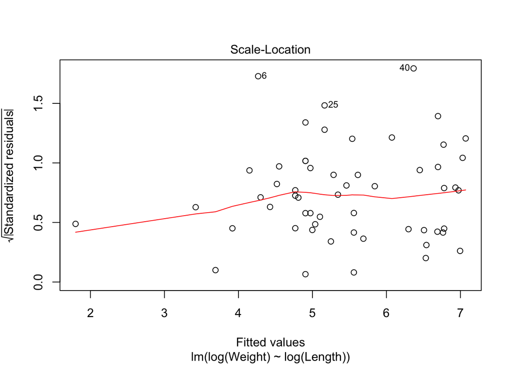

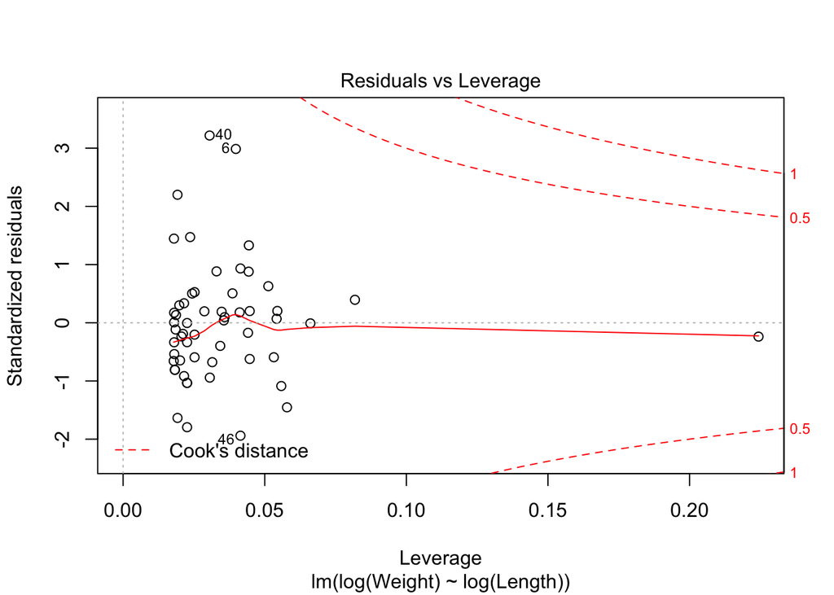

```r
plot(mod3)
```

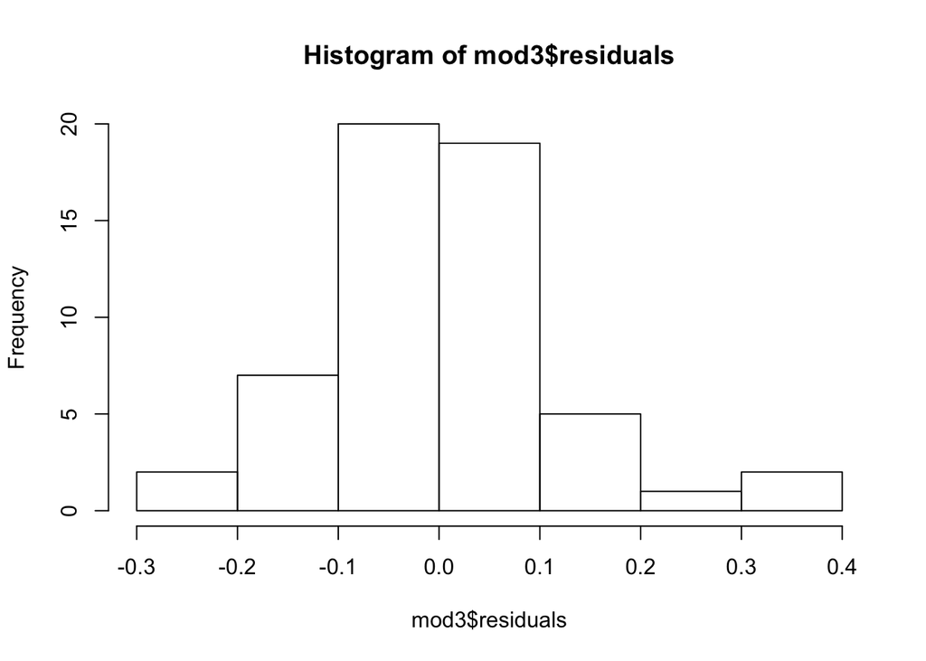

```r
hist(mod3$residuals)
```

I think this relationship between log(Weight)~log(Length) is suited for modeling from a simple linear model. The least squares regression line seems to run right through the data in the first plot. The residuals seem to start off centered around the reference line, but as the fitted values increase the residuals start to deviate from this pattern. The QQ plot shows independence except for the right and left tails where they deviate from the reference line. The histogram shows that the residuals of mod3 seem to be normally distributed and without too much skew. Due to the lecture material through this point, we cannot comment on the normality of the relationship. Overall, this relationship is probably ok to modeled by a simple linear model, however, the model would be improved if we saw better evidence of Zero Mean of the residuals vs fitted values, and the if the standardized residuals didn’t increase so much in the upper right part of the QQ plot.

Question 2, Part D

log(Weight) = -5.07884 + 3.16269*log(Length)

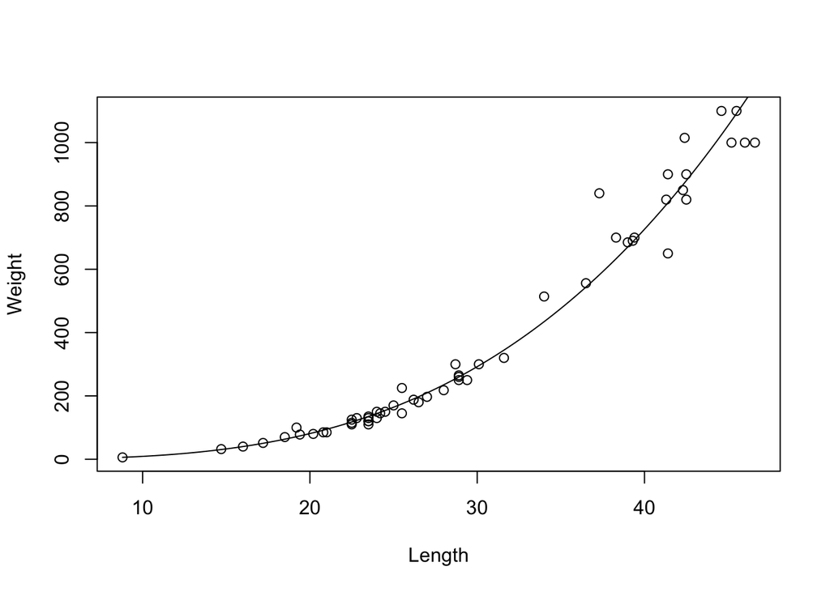

```r
plot(Weight~Length, data = Perch)
curve(0.006227128*(x^3.16269), add=TRUE)
```

The above plot shows a log-linear plot that predicts the relationship between Weight of a Fish and Length of a fish.

```r
PredictedWeight = 0.006227128 * 19^3.16269
PredictedWeight
```

```
## [1] 68.95869
```

Based on this model we would predict a fish with a length of 19cm to weigh 68.95869 grams